# Analyzing Birth & Pregnancy Related Risks and Mortality

## Final Project Delivery

#### Group Members: Mahrukh Khan, ByungJun Kim, Niyatha Malepati

#### December 9th, 2021

## 1) Problem Statement & Context

Childhood malnutrition is a global public health challenge. Children who are malnourished are not able to grow up to their full potential as it hampers their physical and mental growth. Malnutrition is classified into three indicators; stunting, wasting and underweight. Each of these three indicators reflect the child’s growth trajectory as compared to the standards defined by the World Health Organization.

We aim to explore the determinants of childhood malnutrition in the United States. In particular, we want to study the factors that are associated with a child’s development indicators before and after birth. These factors can include but are not limited to the mother’s health, antenatal and postnatal care, dietary patterns of the mother and child, access to clean water, sanitation and hygiene, household income and other household demographics.

#### Data Description

The dataset is the de-identified information on births and infant deaths in Indiana state between 2010 and 2019. Each row is indexed by a de-identified unique ID for each mother and another unique ID for each child. (Link: https://hub.mph.in.gov/dataset/indiana-births-and-infant-deaths)

## 2-1) Dataset Cleaning & Preliminary Explorations

##### In the interest of time and running the analysis in a timely fashion, only 50% of the data was used by randomly sampling 50% of the data with a random_state of 1. For each question, undersampling was performed such that there was a 50-50 ratio between the labels for the respective classification variables.

```python
df.info(verbose=True)
```

```
<class 'pandas.core.frame.DataFrame'>
Int64Index: 406918 entries, 364840 to 304432
Data columns (total 19 columns):
 #   Column                         Non-Null Count   Dtype
---  ------                         --------------   -----
 0   MOTHER_ID                      406918 non-null  object
 1   NUM_BIRTHS_BY_MOTHER           406918 non-null  int64
 2   CHILD_ID                       406918 non-null  object
 3   CHILD_BIRTH_YR_GRP             406918 non-null  object
 4   MOTHER_AGE_GRP                 406918 non-null  object
 5   MOTHER_MARITALSTATUS_AT_BIRTH  406918 non-null  object
 6   MOTHER_RESID_COUNTY_TYPE       406918 non-null  object
 7   BIRTH_COMPLICATIONS            406918 non-null  object
 8   DIABETES_RISK_PREPREGNANCY     406918 non-null  object
 9   DIABETES_RISK_GESTATIONAL      406918 non-null  object
 10  SMOKING_IND                    406918 non-null  object
 11  SMOKING_DURING_PREG_IND        406918 non-null  object
 12  SMOKING_BEFORE_PREG_IND        406918 non-null  object
 13  VISITS_IN_1ST_TRIMESTER_IND    406918 non-null  object
 14  CHILD_GENDER                   406918 non-null  object
 15  CHILD_TRANSFERRED              406918 non-null  object
 16  LOW_BIRTH_WEIGHT               406918 non-null  object
 17  CHILD_BREASTFED                406918 non-null  object
 18  CHILD_ALIVE                    406918 non-null  object
dtypes: int64(1), object(18)
memory usage: 62.1+ MB
```

```python
print('Rows with NAs: ', df.shape[0] - df.dropna().shape[0])
```

```
Rows with NAs:  0
```

##### To deal with categorical variables, we created a data set that simply converts string type categorical variabls to numerical variables.

## 2-2) Data Exploration and Visualizations

##### Understanding strength of linear relationships between variables using correlation tables

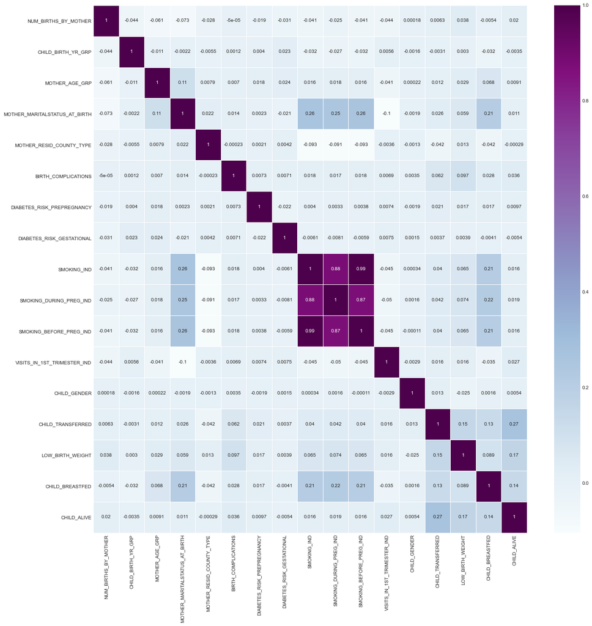

```python
# Remove Mother and Child ID from data for visualizations
df_feats = df.drop(['MOTHER_ID', 'CHILD_ID'], axis=1)

# Show Correlation Heatmap
fig, ax = plt.subplots(figsize=(20,20))
sns.heatmap(df_feats.corr(), annot=True, cmap="BuPu",linewidths=.5, ax=ax)
plt.show()
```

##### We can see that smoking_id is highly correlated to smoking during pregnancy and before pregnancy. Its probably because smoking_id is a column derived from smoking during pregnancy and smoking after pregnancy, dropping smoking ID would make sense.

##### Understanding how low birth weight varies across all the other variables

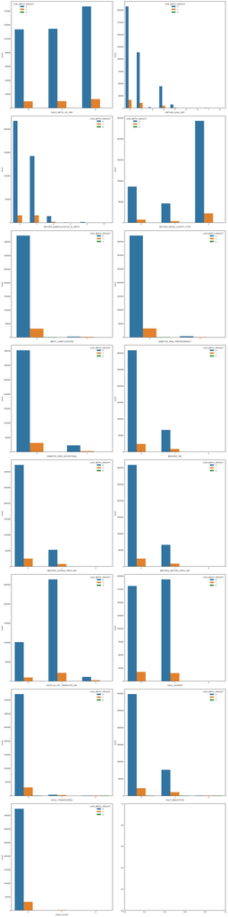

```python
fig, axes = plt.subplots(nrows=8, ncols=2)
fig.set_size_inches(16, 64)

categorical_vars_no_weight = copy.copy(categorical_vars)
categorical_vars_no_weight.remove('LOW_BIRTH_WEIGHT')

for i, var in enumerate(categorical_vars_no_weight):
    if var != 'LOW_BIRTH_WEIGHT':
        sns.countplot(x=var, data=df, hue='LOW_BIRTH_WEIGHT', ax=axes[i//2][i%2])

fig.suptitle('')
fig.tight_layout()
plt.show()
```

## 3) Question Definitions and Choosing Variables

##### 1) Can we predict whether complications during birth will occur based on various factors recorded in the data?

##### If so, what are the relationships between them and their determining factors?

##### Classification Variables: `BIRTH_COMPLICATIONS`

##### 2) Can we predict whether the infant will be born with low weight based on various factors recorded in the data?

##### Classification Variables: `LOW_BIRTH_WEIGHT`

##### 3) Can various demographic, socioeconomic, and health factors be represented in a meaningful fashion to illustrate the relationship between adverse pregnancy outcomes and maternity factors?

##### Classification Variables: None, since unsupervised learning techniques will be used

## 4) Implementation of Analysis

## 4-1) Question 1

#### Question: Can we predict whether complications during birth will occur based on various factors recorded in the data? If so, what are the relationships between them and their determining factors?

#### Classification Variables: `BIRTH_COMPLICATIONS`

#### Models Used: Decision Tree, Random Forest, KNN

### Model Tuning and Validation

#### Model 1: Decision Tree

##### Model Tuning of Multiple Hyperparameters

With reasonable ranges defined, Grid Search CV was done to the model to find perform model tuning and find the best set of hyperparamters to use for the model

```python
# Define model to use for grid search cv
dtc = DecisionTreeClassifier(random_state=1)
# Define values to try for each hyperparameter of random forest classifier to be used in grid search cv
params = {'max_leaf_nodes': range(2, 50),
          'criterion': ['gini', 'entropy'],
          'max_depth': range(1, 20, 1)}
# Define Grid Search CV model
dtc_gs_cv = GridSearchCV(dtc,
                     param_grid=params,
                     scoring='accuracy',
                     cv=10)
# Fit grid search cv model to training data
dtc_gs_cv.fit(X_train, y_train)
# Print best params
print(dtc_gs_cv.best_params_)
```

```
{'criterion': 'gini', 'max_depth': 6, 'max_leaf_nodes': 21}
```

The best hyperparameters found for Decision Tree seems to be one with the max depth of 6, max leaf nodes of 21, and a splitting criterion using the gini method. Using these hyperparameters, a final tuned model is trained on the entire traning set and tested for final performance metric

##### Tuned Decision Tree Performance Metrics & Feature Importance

```python
# Get best values for each hyperparameter
best_max_leaf = dtc_gs_cv.best_params_['max_leaf_nodes']
best_criterion = dtc_gs_cv.best_params_['criterion']
best_depth = dtc_gs_cv.best_params_['max_depth']

# Define new model using the best values for each hyperparameter
dtc = DecisionTreeClassifier(random_state=1, max_leaf_nodes=best_max_leaf, criterion=best_criterion, max_depth=best_depth)
# Fit model to training data
dtc.fit(X_train, y_train)
# Print performance of model
print(dtc.score(X_test, y_test))
print(classification_report(y_test, dtc.predict(X_test)))
```

```
0.6582397003745318
              precision    recall  f1-score   support

           0       0.62      0.80      0.70       533
           1       0.72      0.52      0.60       535

    accuracy                           0.66      1068
   macro avg       0.67      0.66      0.65      1068
weighted avg       0.67      0.66      0.65      1068
```

It seems that after hyperparameter tuning, the decision tree was able to properly classify 65.8% of the test data, meaning that the model was able to predict better than random chance of 50%. Looking at the f-1 scores, it seems that model can reliably predict cases that will not have any birth complications, but has difficulty predicting cases that will have birth complications.

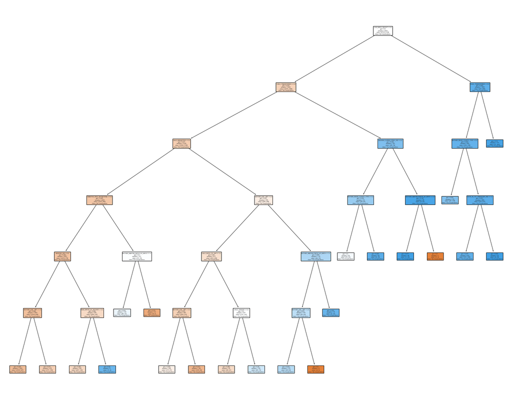

```python
# Print Decision Tree
fig = plt.figure(figsize=(25,20))
plot_tree = tree.plot_tree(dtc,
                           feature_names=X.columns,
                           class_names=['No Complications', 'Yes Complications'],
                           filled=True)
```

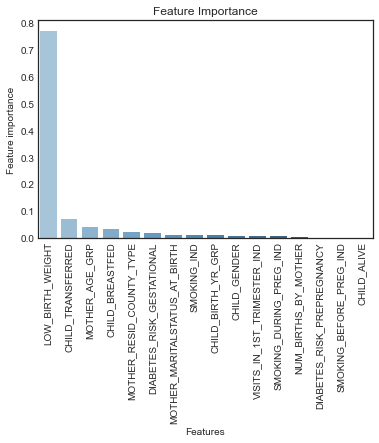

```python
# Get variable importance and turn into dataframe
tree_importances = pd.DataFrame({ 'features': X_train.columns, 'importances': dtc.feature_importances_ })

# Plot variable importance
sns.barplot(x="features",y="importances" ,data=tree_importances,
            order=tree_importances.sort_values('importances',ascending = False).features, palette="Blues_d")
plt.xticks(rotation=90)
plt.title("Feature Importance")
plt.ylabel("Feature importance")
plt.xlabel("Features")
fig.tight_layout()
```

Looking at the feature importance as well as the actual tree, it seems that best indicator for birth complications is low birth weight. As a result, it can be said the estimated birth weight of the infant will likely indicate whether there will be birth complications or not.

#### Model 2: Random Forests

##### Model Tuning of Multiple Hyperparameters

With reasonable ranges defined, Grid Search CV was done to the model to find perform model tuning and find the best set of hyperparamters to use for the model

```python
# Define model to use for grid search cv
rfc = RandomForestClassifier(random_state=1)
# Define values to try for each hyperparameter of random forest classifier to be used in grid search cv
params = {'n_estimators': range(100, 300, 10),
          'criterion': ['gini', 'entropy'],
          'max_depth': range(1, 10, 1)}
# Define Grid Search CV model
rfc_gs_cv = GridSearchCV(rfc,
                     param_grid=params,
                     scoring='accuracy',
                     cv=10)
# Fit grid search cv model to training data
rfc_gs_cv.fit(X_train, y_train)
# Print best params
print(rfc_gs_cv.best_params_)
```

```
{'criterion': 'entropy', 'max_depth': 6, 'n_estimators': 120}
```

##### Tuned Random Forest Performance Metrics & Feature Importance

```python
# Get best values for each hyperparameter
best_n = rfc_gs_cv.best_params_['n_estimators']
best_criterion = rfc_gs_cv.best_params_['criterion']
best_depth = rfc_gs_cv.best_params_['max_depth']

# Define new model using the best values for each hyperparameter
rfc = RandomForestClassifier(random_state=1, n_estimators=best_n, criterion=best_criterion, max_depth=best_depth)
# Fit model to training data
rfc.fit(X_train, y_train)
# Print performance of model
print(rfc.score(X_test, y_test))
print(classification_report(y_test, rfc.predict(X_test)))
```

```
0.6573033707865169
              precision    recall  f1-score   support

           0       0.61      0.85      0.71       533
           1       0.76      0.47      0.58       535

    accuracy                           0.66      1068
   macro avg       0.68      0.66      0.64      1068
weighted avg       0.68      0.66      0.64      1068
```

It seems that after hyperparameter tuning, the random forest classifier was able to properly classify 65.7% of the test data, meaning that the model was able to predict better than random chance of 50%. Looking at the precision, recall, and f-1 scores, it seems that model can reliably predict cases that will not have any birth complications. However, while the model was able to reliably classify that there will be birth complications based on precision, among those classified having birth complications, there was a significant amount of false negatives, meaning that even with a prediction of birth complications, there is a high liklihood that there might not be any and vise versa.

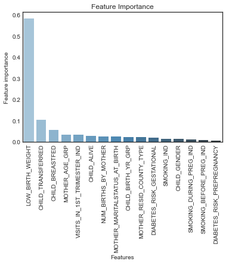

```python
# Get variable importance and turn into dataframe
forest_importances = pd.DataFrame({ 'features': X_train.columns, 'importances': rfc.feature_importances_ })

# Plot variable importance
sns.barplot(x="features",y="importances" ,data=forest_importances,
            order=forest_importances.sort_values('importances',ascending = False).features, palette="Blues_d")
plt.xticks(rotation=90)
plt.title("Feature Importance")
plt.ylabel("Feature importance")
plt.xlabel("Features")
fig.tight_layout()
```

Looking at the feature importance as well as the actual tree, it seems that good indicators for birth complications are low birth weight, whether the child was transferred between facilities after birth, and whether the child was breast fed. As a result, it can be said the estimated birth weight of the infant and whether the infant was transferred and breast fed shortly after birth will likely indicate whether there will be birth related complications or not.

#### Model 3: K-Nearest Neighbors

#### Model Tuning

```
Highest CV Accuracy:  0.6503512880562061
Number of Neighbors for Lowest CV Error:  45
```

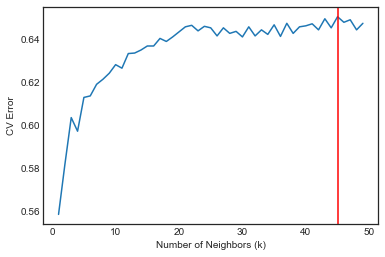

```python
knn_cv_errors = []
for i in range(1,50):
    knn_model = KNeighborsClassifier(n_neighbors=i)
    cv_error = np.mean(cross_val_score(knn_model, X_train, y_train, cv=10))
    knn_cv_errors.append(cv_error)

max_score = np.nanmax(knn_cv_errors)
max_ind = np.nanargmax(knn_cv_errors) + 1
print("Highest CV Accuracy: ", max_score)
print("Number of Neighbors for Lowest CV Error: ", max_ind)
x_graph = list(range(1,50))
plt.plot(x_graph,knn_cv_errors)
plt.xlabel("Number of Neighbors (k)")
plt.ylabel("CV Error")
plt.axvline(max_ind,color="red")
plt.show()
```

Based on the Cross Validation of KNN across multiple k values for number of neighbors, the optimal number of neighbors was found to be 45.

##### Tuned KNN Performance Metrics & Feature Importance

```python
# define KNN model with previously found best number of neighbors
knn = KNeighborsClassifier(n_neighbors=max_ind)
# fit model
knn.fit(X_train,y_train)
y_pred = knn.predict(X_test)
# print accuracy of model using test data
print("KNN Accuracy: ", knn.score(X_test, y_test))
print(classification_report(y_test, rfc.predict(X_test)))
```

```
KNN Accuracy:  0.6301498127340824
              precision    recall  f1-score   support

           0       0.61      0.85      0.71       533
           1       0.76      0.47      0.58       535

    accuracy                           0.66      1068
   macro avg       0.68      0.66      0.64      1068
weighted avg       0.68      0.66      0.64      1068
```

```
<sklearn.metrics._plot.confusion_matrix.ConfusionMatrixDisplay at 0x23a801ee100>
```

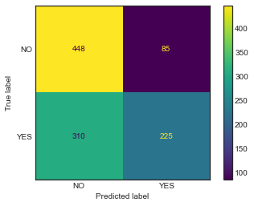

```python
#confusion matrix
knn_cm = confusion_matrix(y_test,y_pred)
knn_cm_display = ConfusionMatrixDisplay(confusion_matrix=knn_cm, display_labels=["NO", "YES"])
knn_cm_display.plot()
```

It seems that after hyperparameter tuning, the KNN classifier was able to properly classify 63.0% of the test data, meaning that the model was able to predict significantly better than random chance of 50%. However, its performance falls short compared to that of the decision tree and random forest model. This is likely due to the fact that all of the features in `X` are categorical variables, which would make it difficult for KNN to classify birth complications by simply taking in neighbors in a limited number space that was converted from categorical values.

### Model Performance & Selection

```python
# Plot the ROC curve for Decision Tree, Random Forest, and K-Nearest Neighbors models

# ROC for Decision Tree
dtc_probs = dtc.predict_proba(X_test)
dtc_auc = roc_auc_score(y_test, dtc_probs[:,1])

dtc_fpr, dtc_tpr, dtc_thresholds = roc_curve(y_test, dtc_probs[:,1])

# ROC for Raondom Forest
rfc_probs = rfc.predict_proba(X_test)
rfc_auc = roc_auc_score(y_test, rfc_probs[:,1])

rfc_fpr, rfc_tpr, rfc_thresholds = roc_curve(y_test, rfc_probs[:,1])

# ROC for KNN
knn_probs = knn.predict_proba(X_test)
knn_auc = roc_auc_score(y_test, knn_probs[:,1])

knn_fpr, knn_tpr, knn_thresholds = roc_curve(y_test, knn_probs[:,1])
```

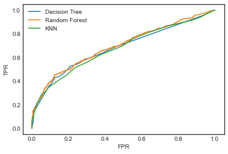

```python
# Show plot of ROC curves
plt.plot(dtc_fpr, dtc_tpr, label = 'Decision Tree')
plt.plot(rfc_fpr, rfc_tpr, label = 'Random Forest')
plt.plot(knn_fpr, knn_tpr, label = 'KNN')
plt.xlabel('FPR')
plt.ylabel('TPR')
plt.legend()
plt.show()
```

The performance of each model was as follows: Decision Tree had an accuracy of 65.8%, while Random Forest had an accuracy of 65.7%, and KNN with an accruacy of 63.0% for the test data. Although the decision tree had the highest overall testing accuracy, the ROC curve that shows the rate of True Positives and False Positives indicates that the Random Forest Model is the best model to predict `BIRTH_COMPLICATIONS`. In the context of this question of determining presence of birth complications, False Positives can be detrimental for both mother and infant, as it would mean that the mother and infant could undergo additional procedures and internventions to prevent a birth complication that actually did not happen or not prepare for a birth complication that could actually heppen in the case of false negatives. This would mean that the patients could be faced with unjustified treatments and increase in hospital charges that were unnecssary. Since the overall performance between Random Forest and Decision Tree were very similar (65.7% for Random Forest and 65.8% for Decision Tree), the best model to address this question on predicting birth complications would be the Random Forest Model.

### Question 1: Conclusion & Discussion

Based on all the results and analysis, it seems that birth-related risks and complications can be reasonably classified based on the various pregnancy and birth related factors in the data. Among the 3 models expored, it seems that random forest was the best model to use when accounting for preicison, recall, as well as False Positive and Negative rates to prevent over-treatment or under-treatment for mothers who may undergo birth complications. From the feature importance analysis of Random Forests and Decision Trees, birth weight had a direct relationship and was the major or only determinig factor in identifying birth complications. As a result, it can be said that birth-related risks and complications can be reasonable classified with birth weight being the determing factor.

## 4-2) Question 2

#### Question: Can we predict whether the infant will be born with low weight based on various factors recorded in the data?

#### Classification Variables: `LOW_BIRTH_WEIGHT`

#### Model Used: KNN, Naive Bayes, Logistic Regression

### Model Training, Tuning, Validation & Testing

```python
#Exclude response variable and id variables from set of predictors
X = df_[df_.columns.difference(['LOW_BIRTH_WEIGHT'])]

#response variable
y = df_['LOW_BIRTH_WEIGHT']
```

```python
#Use random undersampler to deal with imbalance in the data

#generate sampler using 50%-50% ratio for majority and minority classes
rus = RandomUnderSampler(sampling_strategy=1.0)

#resampling X, y
X, y = rus.fit_resample(X, y)

#split resampled X and y into train and test set
X_train, X_test, y_train, y_test = train_test_split(X ,y, test_size=0.20, random_state=1)
```

```python
#Tabulate response variable after resampling
y.value_counts()
```

```
0    32417
1    32417
Name: LOW_BIRTH_WEIGHT, dtype: int64
```

#### KNN

```python
#run a KNN classification model to predict low-birth weight in children
knn = KNeighborsClassifier()
knn.fit(X_train, y_train)
y_pred = knn.predict(X_test)
```

#### KNN Performance Metrics

```python
cv = np.mean(cross_val_score(knn, X, y, scoring='accuracy', cv=5))
print("Average Model Accuracy with 5-fold Cross Validation", cv)
```

```
Average Model Accuracy with 5-fold Cross Validation 0.5564057070035314
```

```python
cm = confusion_matrix(y_test,y_pred)
print(cm)
print(classification_report(y_test, y_pred, digits=3))
```

```
[[3921 2664]
 [2971 3411]]
              precision    recall  f1-score   support

           0      0.569     0.595     0.582      6585
           1      0.561     0.534     0.548      6382

    accuracy                          0.565     12967
   macro avg      0.565     0.565     0.565     12967
weighted avg      0.565     0.565     0.565     12967
```

#### KNN Model Tuning & Validation

The following code uses cross validation to determine optimal number of k-neighbors for the KNN model.

```python
cv_average = []
for k in range(2,25):
    model1 = KNeighborsClassifier(n_neighbors=k)
    cv = np.mean(cross_val_score(model1, X_train, y_train, cv=5))
    cv_average.append(cv)
    print("k =", k)
    print("CV Score: ", cv)
```

```
k = 2
CV Score:  0.5452022294462434
k = 3
CV Score:  0.5524129086667457
k = 4
CV Score:  0.5522587252564369
k = 5
CV Score:  0.5613396816946518
k = 6
CV Score:  0.5591033382907022
k = 7
CV Score:  0.5631519157109379
k = 8
CV Score:  0.5668151944425874
k = 9
CV Score:  0.5682997008944433
k = 10
CV Score:  0.5696493605183676
k = 11
CV Score:  0.5729270264627747
k = 12
CV Score:  0.5724643721518199
k = 13
CV Score:  0.5745851904416396
k = 14
CV Score:  0.574103214416883
k = 15
CV Score:  0.5772265965880969
k = 16
CV Score:  0.5776893456862202
k = 17
CV Score:  0.5800800657919595
k = 18
CV Score:  0.5782870122380085
k = 19
CV Score:  0.5802149497913298
k = 20
CV Score:  0.5775928653586744
k = 21
CV Score:  0.5787882207651143
k = 22
CV Score:  0.5778820907469676
k = 23
CV Score:  0.5796365770747642
k = 24
CV Score:  0.578229156752347
```

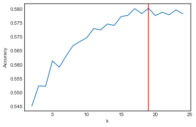

```python
#plot k-neighbors against average model accuracy
k = list(range(2,25))

ax = plt.gca()
ax.plot(k, cv_average)
plt.xlabel('k')
plt.ylabel('Accuracy')
plt.axvline(k[np.argmax(cv_average)], color='red')
```

The maximum accuracy is obtained with k = 19.

#### KNN Revised Performance Metrics

```python
#retrain KNN model
model1 = KNeighborsClassifier(n_neighbors = k[np.argmax(cv_average)])
model1.fit(X_train, y_train)
y_pred = model1.predict(X_test)
```

```python
cv = np.mean(cross_val_score(knn, X, y, scoring='accuracy', cv=5))
print("Average Model Accuracy with 5-fold Cross Validation", cv)
```

```
Average Model Accuracy with 5-fold Cross Validation 0.5564057070035314
```

```python
print(classification_report(y_test, y_pred, digits=3))
```

```
              precision    recall  f1-score   support

           0      0.580     0.667     0.620      6585
           1      0.593     0.501     0.543      6382

    accuracy                          0.585     12967
   macro avg      0.586     0.584     0.582     12967
weighted avg      0.586     0.585     0.582     12967
```

```
<sklearn.metrics._plot.confusion_matrix.ConfusionMatrixDisplay at 0x23aed820fd0>
```

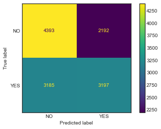

```python
#confusion matrix
knn_cm = confusion_matrix(y_test,y_pred)
knn_cm_display = ConfusionMatrixDisplay(confusion_matrix=knn_cm, display_labels=["NO", "YES"])
knn_cm_display.plot()
```

#### Naive Bayes

```python
#naive bayes model
model2 = GaussianNB()
nb_pred = model2.fit(X_train, y_train).predict(X_test)
```

#### Naive Bayes Performance Metrics

```python
cv = np.mean(cross_val_score(model2, X, y, scoring='accuracy', cv=5))
print("Average Model Accuracy with 5-fold Cross Validation", cv)
```

```
Average Model Accuracy with 5-fold Cross Validation 0.5672794801160019
```

```python
print(classification_report(y_test, nb_pred, digits=3))
```

```
              precision    recall  f1-score   support

           0      0.544     0.967     0.696      6585
           1      0.827     0.165     0.275      6382

    accuracy                          0.572     12967
   macro avg      0.686     0.566     0.486     12967
weighted avg      0.684     0.572     0.489     12967
```

```
<sklearn.metrics._plot.confusion_matrix.ConfusionMatrixDisplay at 0x23ad223bf10>
```

[figure not shown]

```python
#confusion matrix
nb_cm = confusion_matrix(y_test,y_pred)
nb_cm_display = ConfusionMatrixDisplay(confusion_matrix=nb_cm, display_labels=["NO", "YES"])
nb_cm_display.plot()
```

#### Logistic Regression

```python
#logistic regression
model3 = LogisticRegression(random_state=1).fit(X_train, y_train)
X_test_pred = model3.predict(X_test)
```

#### Logistic Regression Performance Metrics

```python
cv = np.mean(cross_val_score(model3, X, y, scoring='accuracy', cv=5))
print("Average Model Accuracy with 5-fold Cross Validation", cv)
```

```
Average Model Accuracy with 5-fold Cross Validation 0.6035876712205087
```

```python
print(classification_report(y_test, X_test_pred))
```

```
              precision    recall  f1-score   support

           0       0.59      0.72      0.65      6585
           1       0.63      0.49      0.55      6382

    accuracy                           0.61     12967
   macro avg       0.61      0.61      0.60     12967
weighted avg       0.61      0.61      0.60     12967
```

```
<sklearn.metrics._plot.confusion_matrix.ConfusionMatrixDisplay at 0x23ae8e4d460>
```

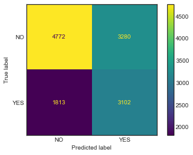

```python
#confusion matrix
logreg_cm = confusion_matrix(y_test, X_test_pred).T
logreg_cm_display = ConfusionMatrixDisplay(confusion_matrix = logreg_cm, display_labels=["NO", "YES"])
logreg_cm_display.plot()
```

Logistic Regression model has an accuracy of 60.4%, similar to Naive Bayes. The precision is 59% and 63% for Class 0 and 1 respectively. The precision is better as compared to KNN but lower for Class 1 as compared to Naive Bayes.

### Model Performance & Selection

```python
#Plot the ROC curve for KNN, Naive Bayes, and Logistic Regression models

#KNN
knn_probs = model1.predict_proba(X_test)
knn_auc = roc_auc_score(y_test, knn_probs[:,1])

knn_fpr, knn_tpr, knn_thresholds = roc_curve(y_test, knn_probs[:,1])

#Naive Bayes
nb_probs = model2.predict_proba(X_test)
nb_auc = roc_auc_score(y_test, nb_probs[:,1])

nb_fpr, nb_tpr, nb_thresholds = roc_curve(y_test, nb_probs[:,1])


#Logistic
logreg_probs = model3.predict_proba(X_test)
logreg_auc = roc_auc_score(y_test, logreg_probs[:,1])

logreg_fpr, logreg_tpr, logreg_thresholds = roc_curve(y_test, logreg_probs[:,1])
```

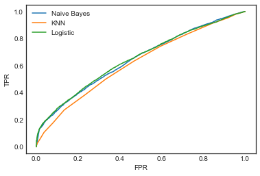

```python
plt.plot(nb_fpr, nb_tpr, label = 'Naive Bayes')
plt.plot(knn_fpr, knn_tpr, label = 'KNN')
plt.plot(logreg_fpr, logreg_tpr, label = 'Logistic')
plt.xlabel('FPR')
plt.ylabel('TPR')
plt.legend()
plt.show()
```

Naive Bayes and Logistic Regression perform better as compared to KNN.

## 4-3) Question 3

#### Question: Can various demographic, socioeconomic, and health factors be represented in a meaningful fashion to illustrate the relationship between adverse pregnancy outcomes and maternity factors?

#### Classification Variables: None, since unsupervised learning techniques will be used

#### Models Used: KModes, KPrototypes

### Clustering

Using unsupervised learning techniques, we'll see if we can find meaningful relationships between adverse pregnancy outcomes and maternity factors using various demographic, socioeconomic, and health factors.

> Since most of the data has categorical data, we will be using Kmodes and Kprototypes algorthims

### Kmodes

> k MODES uses the dissimilarities(total mismatches) between the data points. The lesser the dissimilarities the more similar our data points are. It uses Modes instead of means.

```python
%%time
metrics.silhouette_score(new_cust, clusters_cao,  sample_size=None, random_state=1)
```

```
Wall time: 73.1 ms
```

```
0.06825232778839173
```

##### Sillouette score is 0.07, lets try using huang initialization and check if it improves

#### Lets use Huang Initialization

```python
%%time
metrics.silhouette_score(new_cust, clusters_huang,  sample_size=None, random_state=1)
```

```
Wall time: 75.7 ms
```

```
0.0152971895983549
```

##### Silhouette score is 0.02, has decreased compare to "Cao" method, so we'll stick to default method ( Cao).

#### Choosing a k value looking at cost

Scree Plot or Elbow curve to find optimal K value

For KModes, we will plot cost for a range of K values. Cost is the sum of all the dissimilarities between the clusters.

Selecting the K where we can observe an elbow-like bend with a lesser cost value

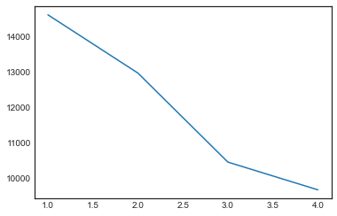

```python
y = np.array([i for i in range(1,5,1)])
plt.plot(y,cost)
```

##### Lets try K = 3, we can check if our score improves!

```python
%%time
# Building the model with default clusters
kmode_cao_tuned = KModes(n_clusters=3,random_state=1)
clusters_cao_tuned = kmode_cao_tuned.fit_predict(new_cust)
clusters_cao_tuned

metrics.silhouette_score(new_cust, clusters_cao_tuned,  sample_size=None, random_state=1)
```

```
Wall time: 628 ms
```

```
0.1656938564837263
```

##### Score has improved to 0.17, let's add clusters to our orginial model

#### Trying K prototype to check if this improves what we already have

```python
## encoding the categorical variables
le = preprocessing.LabelEncoder()
new_cust_v2 = undersampled_data.apply(le.fit_transform)
new_cust_v2.head()
```

|  | NUM_BIRTHS_BY_MOTHER | CHILD_BIRTH_YR_GRP | MOTHER_AGE_GRP | MOTHER_MARITALSTATUS_AT_BIRTH | MOTHER_RESID_COUNTY_TYPE | BIRTH_COMPLICATIONS | DIABETES_RISK_PREPREGNANCY | DIABETES_RISK_GESTATIONAL | SMOKING_IND | SMOKING_DURING_PREG_IND | SMOKING_BEFORE_PREG_IND | VISITS_IN_1ST_TRIMESTER_IND | CHILD_GENDER | CHILD_TRANSFERRED | LOW_BIRTH_WEIGHT | CHILD_BREASTFED | CHILD_ALIVE |
| --- | --- | --- | --- | --- | --- | --- | --- | --- | --- | --- | --- | --- | --- | --- | --- | --- | --- |
| 0 | 2 | 2 | 3 | 1 | 2 | 0 | 0 | 0 | 0 | 0 | 0 | 2 | 1 | 0 | 0 | 0 | 0 |
| 1 | 0 | 0 | 3 | 0 | 1 | 0 | 0 | 0 | 2 | 2 | 2 | 1 | 1 | 0 | 2 | 0 | 0 |
| 2 | 1 | 2 | 3 | 1 | 2 | 0 | 0 | 0 | 0 | 0 | 0 | 2 | 0 | 2 | 0 | 0 | 0 |
| 3 | 2 | 2 | 3 | 1 | 2 | 0 | 0 | 0 | 0 | 0 | 0 | 2 | 1 | 0 | 2 | 0 | 0 |
| 4 | 0 | 2 | 3 | 1 | 2 | 0 | 0 | 0 | 0 | 0 | 0 | 2 | 0 | 0 | 2 | 0 | 0 |

```python
%%time
metrics.silhouette_score(new_cust_v2, pred,  metric='euclidean', sample_size=None, random_state=1)
```

```
Wall time: 77.1 ms
```

```
0.21664995
```

### Cluster Group Identification

#### Let's understand distinct characteristics of each cluster!

#### Cluster 0

Cluster 0 -- Low Risk Group

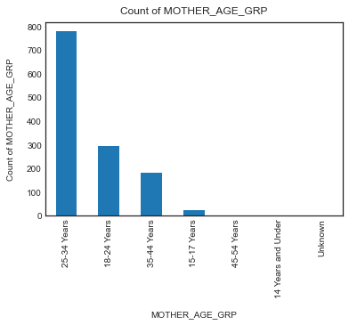

```python
cluster_0['MOTHER_AGE_GRP'].value_counts().plot(kind='bar')
plt.xlabel("MOTHER_AGE_GRP", labelpad=14)
plt.ylabel("Count of MOTHER_AGE_GRP", labelpad=14)
plt.title("Count of MOTHER_AGE_GRP", y=1.02);
```

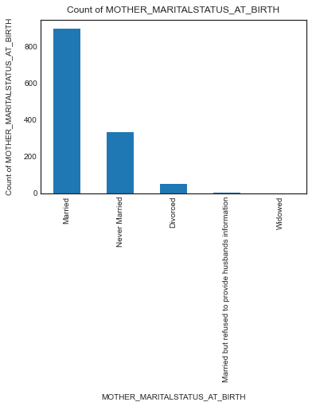

```python
cluster_0['MOTHER_MARITALSTATUS_AT_BIRTH'].value_counts().plot(kind='bar')
plt.xlabel("MOTHER_MARITALSTATUS_AT_BIRTH", labelpad=14)
plt.ylabel("Count of MOTHER_MARITALSTATUS_AT_BIRTH", labelpad=14)
plt.title("Count of MOTHER_MARITALSTATUS_AT_BIRTH", y=1.02);
```

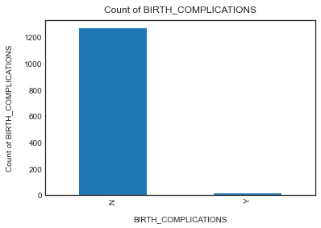

```python
cluster_0['BIRTH_COMPLICATIONS'].value_counts().plot(kind='bar')
plt.xlabel("BIRTH_COMPLICATIONS", labelpad=14)
plt.ylabel("Count of BIRTH_COMPLICATIONS", labelpad=14)
plt.title("Count of BIRTH_COMPLICATIONS", y=1.02);
```

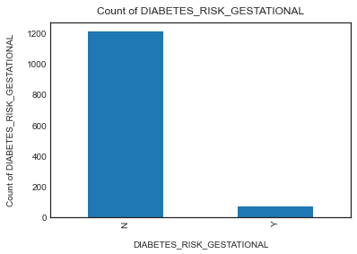

```python
cluster_0['DIABETES_RISK_GESTATIONAL'].value_counts().plot(kind='bar')
plt.xlabel("DIABETES_RISK_GESTATIONAL", labelpad=14)
plt.ylabel("Count of DIABETES_RISK_GESTATIONAL", labelpad=14)
plt.title("Count of DIABETES_RISK_GESTATIONAL", y=1.02);
```

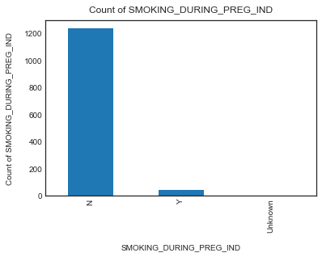

```python
cluster_0['SMOKING_DURING_PREG_IND'].value_counts().plot(kind='bar')
plt.xlabel("SMOKING_DURING_PREG_IND", labelpad=14)
plt.ylabel("Count of SMOKING_DURING_PREG_IND", labelpad=14)
plt.title("Count of SMOKING_DURING_PREG_IND", y=1.02);
```

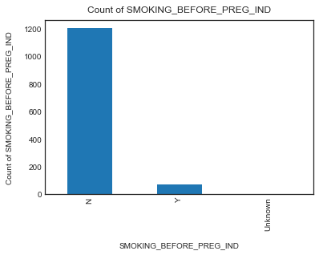

```python
cluster_0['SMOKING_BEFORE_PREG_IND'].value_counts().plot(kind='bar')
plt.xlabel("SMOKING_BEFORE_PREG_IND", labelpad=14)
plt.ylabel("Count of SMOKING_BEFORE_PREG_IND", labelpad=14)
plt.title("Count of SMOKING_BEFORE_PREG_IND", y=1.02);
```

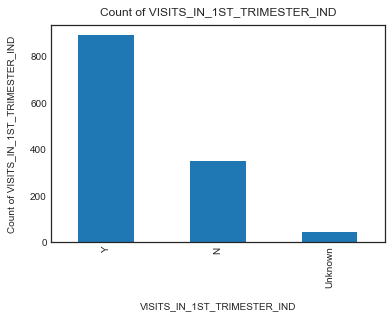

```python
cluster_0['VISITS_IN_1ST_TRIMESTER_IND'].value_counts().plot(kind='bar')
plt.xlabel("VISITS_IN_1ST_TRIMESTER_IND", labelpad=14)
plt.ylabel("Count of VISITS_IN_1ST_TRIMESTER_IND", labelpad=14)
plt.title("Count of VISITS_IN_1ST_TRIMESTER_IND", y=1.02);
```

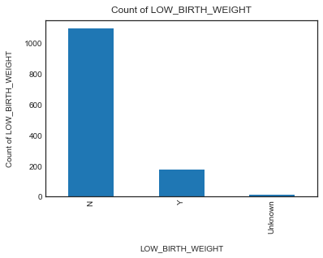

```python
cluster_0['LOW_BIRTH_WEIGHT'].value_counts().plot(kind='bar')
plt.xlabel("LOW_BIRTH_WEIGHT", labelpad=14)
plt.ylabel("Count of LOW_BIRTH_WEIGHT", labelpad=14)
plt.title("Count of LOW_BIRTH_WEIGHT", y=1.02);
```

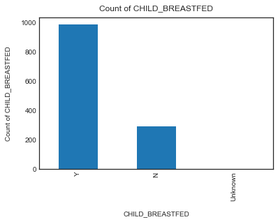

```python
cluster_0['CHILD_BREASTFED'].value_counts().plot(kind='bar')
plt.xlabel("CHILD_BREASTFED", labelpad=14)
plt.ylabel("Count of CHILD_BREASTFED", labelpad=14)
plt.title("Count of CHILD_BREASTFED", y=1.02);
```

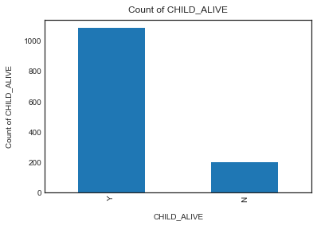

```python
cluster_0['CHILD_ALIVE'].value_counts().plot(kind='bar')
plt.xlabel("CHILD_ALIVE", labelpad=14)
plt.ylabel("Count of CHILD_ALIVE", labelpad=14)
plt.title("Count of CHILD_ALIVE", y=1.02);
```

#### Cluster 1

Cluster 1 -- High Risk Group

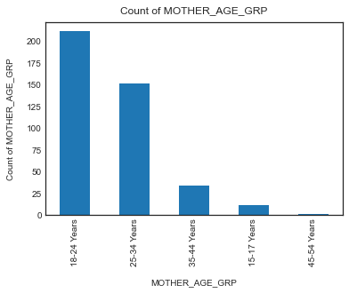

```python
cluster_1['MOTHER_AGE_GRP'].value_counts().plot(kind='bar')
plt.xlabel("MOTHER_AGE_GRP", labelpad=14)
plt.ylabel("Count of MOTHER_AGE_GRP", labelpad=14)
plt.title("Count of MOTHER_AGE_GRP", y=1.02);
```

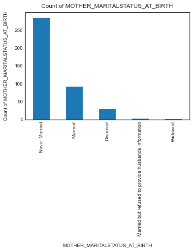

```python
cluster_1['MOTHER_MARITALSTATUS_AT_BIRTH'].value_counts().plot(kind='bar')
plt.xlabel("MOTHER_MARITALSTATUS_AT_BIRTH", labelpad=14)
plt.ylabel("Count of MOTHER_MARITALSTATUS_AT_BIRTH", labelpad=14)
plt.title("Count of MOTHER_MARITALSTATUS_AT_BIRTH", y=1.02);
```

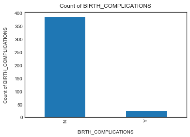

```python
cluster_1['BIRTH_COMPLICATIONS'].value_counts().plot(kind='bar')
plt.xlabel("BIRTH_COMPLICATIONS", labelpad=14)
plt.ylabel("Count of BIRTH_COMPLICATIONS", labelpad=14)
plt.title("Count of BIRTH_COMPLICATIONS", y=1.02);
```

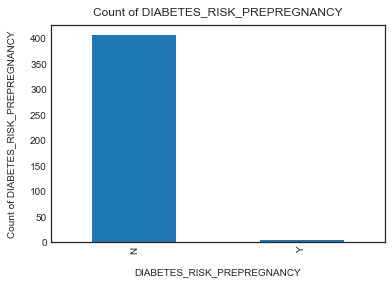

```python
cluster_1['DIABETES_RISK_PREPREGNANCY'].value_counts().plot(kind='bar')
plt.xlabel("DIABETES_RISK_PREPREGNANCY", labelpad=14)
plt.ylabel("Count of DIABETES_RISK_PREPREGNANCY", labelpad=14)
plt.title("Count of DIABETES_RISK_PREPREGNANCY", y=1.02);
```

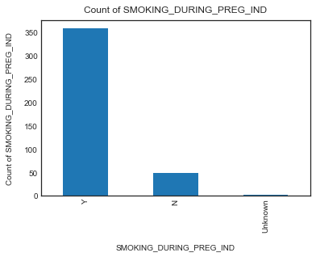

```python
cluster_1['SMOKING_DURING_PREG_IND'].value_counts().plot(kind='bar')
plt.xlabel("SMOKING_DURING_PREG_IND", labelpad=14)
plt.ylabel("Count of SMOKING_DURING_PREG_IND", labelpad=14)
plt.title("Count of SMOKING_DURING_PREG_IND", y=1.02);
```

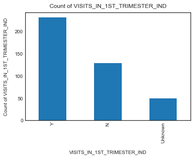

```python
cluster_1['VISITS_IN_1ST_TRIMESTER_IND'].value_counts().plot(kind='bar')
plt.xlabel("VISITS_IN_1ST_TRIMESTER_IND", labelpad=14)
plt.ylabel("Count of VISITS_IN_1ST_TRIMESTER_IND", labelpad=14)
plt.title("Count of VISITS_IN_1ST_TRIMESTER_IND", y=1.02);
```

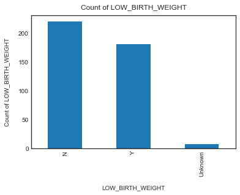

```python
cluster_1['LOW_BIRTH_WEIGHT'].value_counts().plot(kind='bar')
plt.xlabel("LOW_BIRTH_WEIGHT", labelpad=14)
plt.ylabel("Count of LOW_BIRTH_WEIGHT", labelpad=14)
plt.title("Count of LOW_BIRTH_WEIGHT", y=1.02);
```

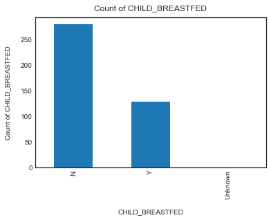

```python
cluster_1['CHILD_BREASTFED'].value_counts().plot(kind='bar')
plt.xlabel("CHILD_BREASTFED", labelpad=14)
plt.ylabel("Count of CHILD_BREASTFED", labelpad=14)
plt.title("Count of CHILD_BREASTFED", y=1.02);
```

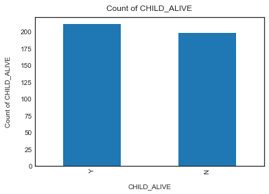

```python
cluster_1['CHILD_ALIVE'].value_counts().plot(kind='bar')
plt.xlabel("CHILD_ALIVE", labelpad=14)
plt.ylabel("Count of CHILD_ALIVE", labelpad=14)
plt.title("Count of CHILD_ALIVE", y=1.02);
```

#### Cluster 2

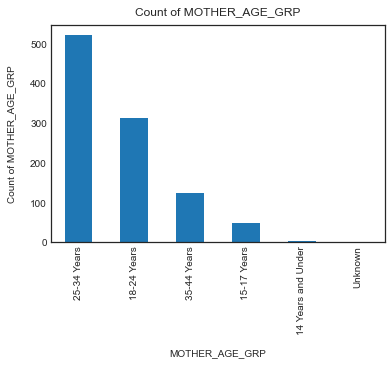

```python
cluster_2['MOTHER_AGE_GRP'].value_counts().plot(kind='bar')
plt.xlabel("MOTHER_AGE_GRP", labelpad=14)
plt.ylabel("Count of MOTHER_AGE_GRP", labelpad=14)
plt.title("Count of MOTHER_AGE_GRP", y=1.02);
```

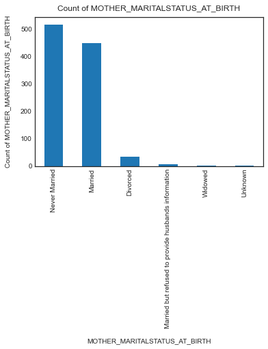

```python
cluster_2['MOTHER_MARITALSTATUS_AT_BIRTH'].value_counts().plot(kind='bar')
plt.xlabel("MOTHER_MARITALSTATUS_AT_BIRTH", labelpad=14)
plt.ylabel("Count of MOTHER_MARITALSTATUS_AT_BIRTH", labelpad=14)
plt.title("Count of MOTHER_MARITALSTATUS_AT_BIRTH", y=1.02);
```

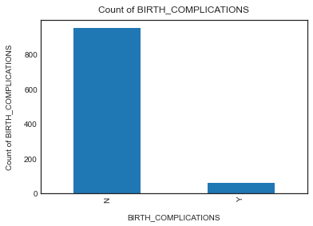

```python
cluster_2['BIRTH_COMPLICATIONS'].value_counts().plot(kind='bar')
plt.xlabel("BIRTH_COMPLICATIONS", labelpad=14)
plt.ylabel("Count of BIRTH_COMPLICATIONS", labelpad=14)
plt.title("Count of BIRTH_COMPLICATIONS", y=1.02);
```

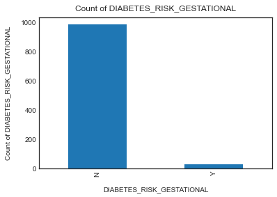

```python
cluster_2['DIABETES_RISK_GESTATIONAL'].value_counts().plot(kind='bar')
plt.xlabel("DIABETES_RISK_GESTATIONAL", labelpad=14)
plt.ylabel("Count of DIABETES_RISK_GESTATIONAL", labelpad=14)
plt.title("Count of DIABETES_RISK_GESTATIONAL", y=1.02);
```

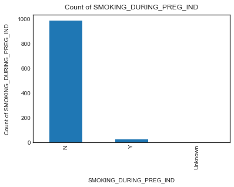

```python
cluster_2['SMOKING_DURING_PREG_IND'].value_counts().plot(kind='bar')
plt.xlabel("SMOKING_DURING_PREG_IND", labelpad=14)
plt.ylabel("Count of SMOKING_DURING_PREG_IND", labelpad=14)
plt.title("Count of SMOKING_DURING_PREG_IND", y=1.02);
```

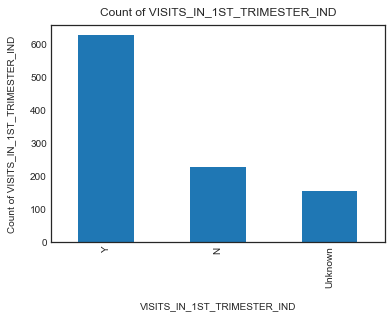

```python
cluster_2['VISITS_IN_1ST_TRIMESTER_IND'].value_counts().plot(kind='bar')
plt.xlabel("VISITS_IN_1ST_TRIMESTER_IND", labelpad=14)
plt.ylabel("Count of VISITS_IN_1ST_TRIMESTER_IND", labelpad=14)
plt.title("Count of VISITS_IN_1ST_TRIMESTER_IND", y=1.02);
```

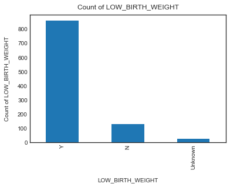

```python
cluster_2['LOW_BIRTH_WEIGHT'].value_counts().plot(kind='bar')
plt.xlabel("LOW_BIRTH_WEIGHT", labelpad=14)
plt.ylabel("Count of LOW_BIRTH_WEIGHT", labelpad=14)
plt.title("Count of LOW_BIRTH_WEIGHT", y=1.02);
```

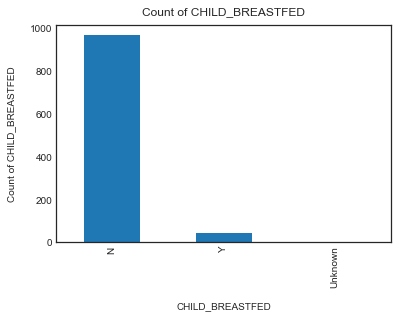

```python
cluster_2['CHILD_BREASTFED'].value_counts().plot(kind='bar')
plt.xlabel("CHILD_BREASTFED", labelpad=14)
plt.ylabel("Count of CHILD_BREASTFED", labelpad=14)
plt.title("Count of CHILD_BREASTFED", y=1.02);
```

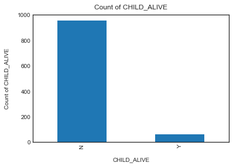

```python
cluster_2['CHILD_ALIVE'].value_counts().plot(kind='bar')
plt.xlabel("CHILD_ALIVE", labelpad=14)
plt.ylabel("Count of CHILD_ALIVE", labelpad=14)
plt.title("Count of CHILD_ALIVE", y=1.02);
```

## 5) Future Work

Going forward, further addition of various pregnancy and birth factors, such as the mother's dietary habits, kinds of prenatal care, and other social determinants of health, will likely result in better preformances. The current features in the data only have very limited social factors like residence type, marital status, and age, and even more limited prenatal information like smoking and diabetes. More information on these topics such as dietary habits, mother's previous health like blood pressure, past diseases and drug intake, will further help determine the risks of birth just as birth weight has in this analysis. In addition, including data points beyond those from the state of Indiana as well as inclusion of other data points in this full dataset will certainly change the outcome of the model. Thus, future work should consider more data at the state level with more information on prenatal care, social and health factors of the model. Lastly, future work should also look into better methods of dealing with imbalanced data besides just simply sampling the data as a 50-50 ratio by accounting for location, year, and type of features included in the data for a more detailed analysis and prediction on birth complications.

### REFERENCES

- Classification Excercise part 1 & 2 work & solutions
- Clustering Excercise part 1 & 2 work & solutions
- Lab 2 work & solutions
- Lab 3 work & solutions
- Lab 4 work & solutions
- HW 2 work & solutions
- HW 3 work
- Data Cleaning and Question Definition
- Project and Group Definition
- https://www.kaggle.com/ashydv/bank-customer-clustering-k-modes-clustering
- https://www.analyticsvidhya.com/blog/2021/06/kmodes-clustering-algorithm-for-categorical-data/
- https://www.kaggle.com/rohanadagouda/unsupervised-learning-using-k-prototype-and-dbscan#Data-Modelling
- https://www.analyticsvidhya.com/blog/2019/05/beginners-guide-hierarchical-clustering/
- https://medium.com/analytics-vidhya/customer-segmentation-using-k-prototypes-algorithm-in-python-aad4acbaaede
- https://stackabuse.com/hierarchical-clustering-with-python-and-scikit-learn/
- https://towardsdatascience.com/clustering-on-numerical-and-categorical-features-6e0ebcf1cbad
- https://stats.stackexchange.com/questions/15287/hierarchical-clustering-with-mixed-type-data-what-distance-similarity-to-use
- https://medium.com/@shailja.nitp2013/k-modesclustering-ef6d9ef06449
- https://datascience.stackexchange.com/questions/64455/how-to-evaluate-the-k-modes-clusters
- https://towardsdatascience.com/clustering-on-numerical-and-categorical-features-6e0ebcf1cbad
- https://www.analyticsvidhya.com/blog/2020/10/quick-guide-to-evaluation-metrics-for-supervised-and-unsupervised-machine-learning/
- https://towardsdatascience.com/clustering-algorithms-a-one-stop-shop-6cd0959f9b8f
- https://towardsdatascience.com/how-to-sample-a-dataframe-in-python-pandas-d18a3187139b
- https://machinelearningmastery.com/random-oversampling-and-undersampling-for-imbalanced-classification/
- https://towardsdatascience.com/clustering-algorithms-a-one-stop-shop-6cd0959f9b8f